# Assignment 5-Copy1

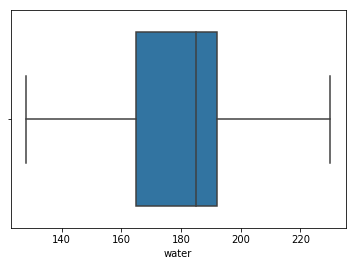

```python
sns.boxplot(X['water'])
```

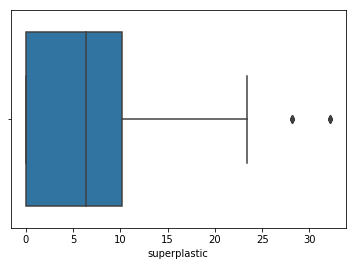

```python
sns.boxplot(X['superplastic'])
```

We observe an outlier in superplastic data. As it is on higher side of the spectrum and this ingredient plays a role in suggesting the strength of concrete so we will replace the outlier with the border value.

```python
print('IQR for superplastic:')
iqr_sp= np.percentile(X['superplastic'],75)-np.percentile(X['superplastic'],25)
iqr_sp
print('Finding the border values for superplastic')
bv_sp_right = iqr_sp * 1.5 + np.percentile(X['superplastic'],75)
bv_sp_right
```

```
IQR for superplastic:
Finding the border values for superplastic
```

```
25.5
```

```python
print('Replacing the right whisker side outliers with the border values, here with 25.5')
X.superplastic.loc[X.superplastic>25.5] = 25.5
```

```
Replacing the right whisker side outliers with the border values, here with 25.5
```

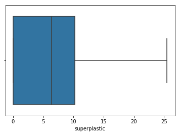

```python
sns.boxplot(X['superplastic'])
```

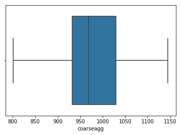

```python
sns.boxplot(X['coarseagg'])
```

seems there is no outlier in coarse aggregate data

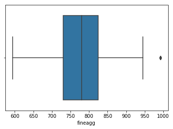

```python
sns.boxplot(X['fineagg'])
```

We observe an outlier in fine aggregate data. As it is on higher side of the spectrum and this ingredient plays a role in suggesting the strength of concrete so we will replace the outlier with the border value.

```python
print('IQR for fine aggregate:')
iqr_fa= np.percentile(X['fineagg'],75)-np.percentile(X['fineagg'],25)
iqr_fa
print('Finding the border values for fine aggregate')
bv_fa_right = iqr_fa * 1.5 + np.percentile(X['fineagg'],75)
bv_fa_right
```

```
IQR for fine aggregate:
Finding the border values for fine aggregate
```

```
963.575
```

```python
print('Replacing the right whisker side outliers with the border values, here with 960')
X.fineagg.loc[X.fineagg>960] = 960
```

```
Replacing the right whisker side outliers with the border values, here with 960
```

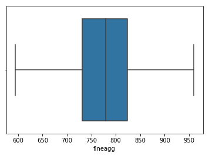

```python
sns.boxplot(X['fineagg'])
```

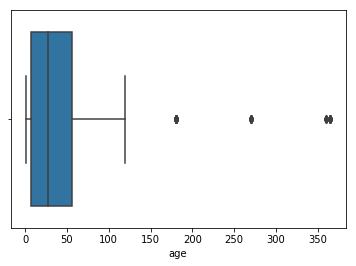

```python
sns.boxplot(X['age'])
```

We observe outliers in age data. As it is on higher side of the spectrum and this ingredient plays a role in suggesting the strength of concrete so we will replace the outlier with the border value

```python
print('IQR for age:')
iqr_age= np.percentile(X['age'],75)-np.percentile(X['age'],25)
iqr_age
print('Finding the border values for age')
bv_age_right = iqr_age * 1.5 + np.percentile(X['age'],75)
bv_age_right
```

```
IQR for age:
Finding the border values for age
```

```
129.5
```

```python
print('Replacing the right whisker side outliers with the border values, here with 129')
X.age.loc[X.age>129] = 129
```

```
Replacing the right whisker side outliers with the border values, here with 129
```

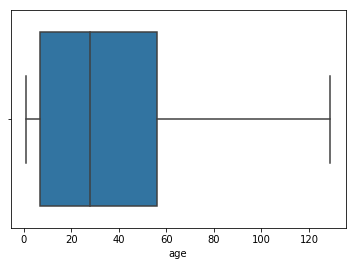

```python
sns.boxplot(X['age'])
```

```python
# Split X and y into training and test set in 70:30 ratio
# We will not create validation set
from sklearn.model_selection import train_test_split # Sklearn package's randomized data splitting function
X_train, X_test, y_train, y_test = train_test_split(X, y, test_size=0.30, random_state=1)
```

```python
from sklearn.preprocessing import StandardScaler
scaler = StandardScaler()
scaled = scaler.fit(X_train)
scaled_train = scaler.transform(X_train)

scaled_test = scaler.transform(X_test)
```

# Fit Linear Model

```python
from sklearn.linear_model import LinearRegression
regression_model = LinearRegression()
regression_model.fit(scaled_train, y_train)
```

```
LinearRegression(copy_X=True, fit_intercept=True, n_jobs=None,
         normalize=False)
```

```python
print('Coefficients for each variable and the intercept:')
for idx, col_name in enumerate(X_train.columns):
    print("The coefficient for {} is {}".format(col_name, regression_model.coef_[0][idx]))
intercept = regression_model.intercept_[0]
print("The intercept for our model is {}".format(intercept))
```

```
Coefficients for each variable and the intercept:
The coefficient for cement is 12.768782681650865
The coefficient for slag is 8.85586209102022
The coefficient for ash is 5.31829823186204
The coefficient for water is -3.153993119745378
The coefficient for superplastic is 1.7065766772766664
The coefficient for coarseagg is 1.1465045575715873
The coefficient for fineagg is 1.8191642062037265
The coefficient for age is 9.10158646197982
The intercept for our model is 35.75618585298197
```

```python
print('The score (R^2) for Train data :')
regression_model.score(scaled_train, y_train)
```

```
The score (R^2) for Train data :
```

```
0.7260706738949034
```

```python
print('The score (R^2) for Test data :')
regression_model.score(scaled_test, y_test)
```

```
The score (R^2) for Test data :
```

```
0.7339340471253458
```

# Create a regularized Ridge model and note the coefficients

```python
from sklearn.linear_model import Ridge
ridge = Ridge(alpha=.3)
ridge.fit(scaled_train,y_train)
print ("Ridge model:", (ridge.coef_))
```

```
Ridge model: [[12.69065505  8.78012511  5.25018833 -3.20416251  1.70803477  1.09604961
   1.75340359  9.09496068]]
```

```python
print(ridge.score(scaled_train, y_train))
print(ridge.score(scaled_test, y_test))
```

```
0.7260675075874315
0.7341186028386646
```

# Create a regularized LASSO model and note the coefficients

```python
from sklearn.linear_model import Lasso
lasso = Lasso(alpha=0.1)
lasso.fit(scaled_train,y_train)
print ("Lasso model:", (lasso.coef_))
```

```
Lasso model: [10.89339466  7.01286815  3.64445197 -4.31115378  1.7287063  -0.
  0.18905025  8.91279936]
```

```python
print(lasso.score(scaled_train, y_train))
print(lasso.score(scaled_test, y_test))
```

```
0.7241236629601371
0.7373403065811479
```

# We do not see any improvement in model performance using Ridge or Lasso model

# It is not a good performance with given data without any transformation or dropping or complex variables.

# We will now include composite variables to check for the performance improvement

```python
from sklearn.preprocessing import PolynomialFeatures
from sklearn import linear_model

poly = PolynomialFeatures(degree=2, interaction_only=True)
X_train2 = poly.fit_transform(scaled_train)
X_test2 = poly.fit_transform(scaled_test)

poly_clf = linear_model.LinearRegression()

poly_clf.fit(X_train2, y_train)

poly_pred = poly_clf.predict(X_test2)
```

```python
#The score (R^2) for Train data with composite variables:
print(poly_clf.score(X_train2, y_train))
```

```
0.8016023034949528
```

```python
#The score (R^2) for Test data with composite variables:
print(poly_clf.score(X_test2, y_test))
```

```
0.7735586435055641
```

Lets try with having Interactions_only as False

```python
from sklearn.preprocessing import PolynomialFeatures
from sklearn import linear_model

poly = PolynomialFeatures(degree=2, interaction_only=False)
X_train2 = poly.fit_transform(scaled_train)
X_test2 = poly.fit_transform(scaled_test)

poly_clf1 = linear_model.LinearRegression()

poly_clf1.fit(X_train2, y_train)

poly_pred = poly_clf1.predict(X_test2)
```

```python
#The score (R^2) for Train data with composite variables:
print(poly_clf1.score(X_train2, y_train))
```

```
0.8678172856461626
```

```python
#The score (R^2) for Test data with composite variables:
print(poly_clf1.score(X_test2, y_test))
```

```
0.8391112641457606
```

```python
X_train2.shape
```

```
(721, 45)
```

Hence we will be using polynomial expression with interface only as False

# In sample (training) R^2 will always improve with the number of variables! And also there is an imrovement in test data

# Create a regularized RIDGE model and note the coefficients

```python
from sklearn.linear_model import Ridge
ridge1 = Ridge(alpha=0.3)
ridge1.fit(X_train2,y_train)
print ("Ridge model:", (ridge.coef_))
```

```
Ridge model: [[12.69065505  8.78012511  5.25018833 -3.20416251  1.70803477  1.09604961
   1.75340359  9.09496068]]
```

```python
print(ridge1.score(X_train2, y_train))
print(ridge1.score(X_test2, y_test))
```

```
0.8676064408145753
0.8391039947969777
```

# find optimal alpha with grid search

```python
from sklearn.model_selection import GridSearchCV
alpha = [0.3, 0.5, 0.7,1,3,5,10,100]

param_grid = dict(alpha=alpha)
grid = GridSearchCV(estimator=ridge, param_grid=param_grid, scoring='r2', verbose=1, n_jobs=-1)
grid_result = grid.fit(X_train2, y_train)
print('Best Score: ', grid_result.best_score_)
print('Best Params: ', grid_result.best_params_)
```

```
Fitting 3 folds for each of 8 candidates, totalling 24 fits
Best Score:  0.8331045583723881
Best Params:  {'alpha': 3}
```

```
[Parallel(n_jobs=-1)]: Done  24 out of  24 | elapsed:    5.1s finished
```

Hence we will use alpha as 3 as suggested by Gridsearch CV

```python
from sklearn.linear_model import Ridge
ridge2 = Ridge(alpha=3)
ridge2.fit(X_train2,y_train)
print ("Ridge model:", (ridge2.coef_))
```

```
Ridge model: [[ 0.00000000e+00  1.29273359e+01  8.51733891e+00  3.19331815e+00
  -3.35760345e+00  1.79370732e+00  1.03746327e+00  1.57273408e+00
   1.50443406e+01 -1.17796279e+00 -3.65017707e-01  1.51196336e+00
  -5.33527196e+00 -3.04675046e+00  3.35855797e-02 -2.51096100e+00
   5.82871475e-02 -1.36042628e-03  2.39844804e+00 -2.19824285e+00
  -1.02927177e+00  9.02893646e-01 -2.62229983e-01  9.81638255e-01
   1.98076863e+00 -1.97633751e+00 -2.95524860e+00  1.88437709e+00
   1.04014426e+00  3.11126049e-01 -2.15447776e+00 -2.11078391e+00
  -3.19415425e+00 -4.08602140e+00 -8.41711620e-02 -1.65393771e+00
  -1.52827666e+00 -1.73865116e+00  3.38721779e-02 -4.21556660e-02
  -9.56477704e-02  2.40845201e-01 -2.13269597e+00 -2.16679387e-01
  -5.08837076e+00]]
```

```python
print(ridge2.score(X_train2, y_train))
print(ridge2.score(X_test2, y_test))
```

```
0.8654415214025895
0.8361419513491117
```

# Create a regularized LASSO model and note the coefficients

```python
from sklearn.linear_model import Lasso
lasso1 = Lasso(alpha=0.1)
lasso1.fit(X_train2,y_train)
print ("Lasso model:", (lasso1.coef_))
```

```
Lasso model: [ 0.00000000e+00  1.08547167e+01  6.41895833e+00  1.69556970e+00
 -4.16708387e+00  1.73576724e+00 -0.00000000e+00  9.71465078e-03
  1.48093300e+01 -2.28114740e-01 -1.79360576e-01  0.00000000e+00
 -1.53675292e+00 -0.00000000e+00  1.56932279e-01 -8.12282578e-01
 -1.18388647e-01 -3.60726509e-01  0.00000000e+00  0.00000000e+00
  1.13882417e+00  0.00000000e+00  2.84414673e-02  6.81670812e-01
  0.00000000e+00 -0.00000000e+00 -3.91983081e-01  3.26885671e-01
  5.98874480e-01  0.00000000e+00 -3.79490642e-02 -0.00000000e+00
 -6.90503116e-01 -9.41272307e-01 -0.00000000e+00 -1.47023067e+00
  4.69223489e-01  3.25448048e-01  6.99131108e-02 -3.67685960e-02
  4.48894110e-01  1.23036070e-01 -1.15672353e+00 -2.52587668e-01
 -4.91946091e+00]
```

```python
print ("Lasso model:", (lasso1.sparse_coef_))
```

```
Lasso model:   (0, 1)	10.85471666740853
  (0, 2)	6.418958326963765
  (0, 3)	1.6955696963359963
  (0, 4)	-4.167083871346816
  (0, 5)	1.7357672373913022
  (0, 7)	0.009714650778111705
  (0, 8)	14.809330027664636
  (0, 9)	-0.22811474038277002
  (0, 10)	-0.17936057619195972
  (0, 12)	-1.5367529184687903
  (0, 14)	0.15693227918546057
  (0, 15)	-0.8122825777347403
  (0, 16)	-0.11838864665139316
  (0, 17)	-0.36072650944512924
  (0, 20)	1.1388241686330804
  (0, 22)	0.028441467326544314
  (0, 23)	0.6816708121594273
  (0, 26)	-0.3919830809237252
  (0, 27)	0.32688567125260853
  (0, 28)	0.5988744799958192
  (0, 30)	-0.03794906421612983
  (0, 32)	-0.6905031158889144
  (0, 33)	-0.9412723073890642
  (0, 35)	-1.4702306747660654
  (0, 36)	0.469223488502542
  (0, 37)	0.3254480484698136
  (0, 38)	0.06991311079566868
  (0, 39)	-0.036768595966333605
  (0, 40)	0.44889411006266594
  (0, 41)	0.12303606962233625
  (0, 42)	-1.1567235272438738
  (0, 43)	-0.2525876675206984
  (0, 44)	-4.919460914997623
```

```python
print(lasso1.score(X_train2, y_train))
print(lasso1.score(X_test2, y_test))
```

```
0.8529395479574313
0.8284559413233934
```

# Find optimal alpha with Grid search

```python
from sklearn.model_selection import GridSearchCV
alpha = [0.01,0.02,0.05,0.1,0.3, 0.5, 0.7,1,3,5,10,100]

param_grid = dict(alpha=alpha)
grid = GridSearchCV(estimator=lasso, param_grid=param_grid, scoring='r2', verbose=1, n_jobs=-1)
grid_result = grid.fit(X_train2, y_train)
print('Best Score: ', grid_result.best_score_)
print('Best Params: ', grid_result.best_params_)
```

```
Fitting 3 folds for each of 12 candidates, totalling 36 fits
Best Score:  0.8333244743690195
Best Params:  {'alpha': 0.02}
```

Let's put the alpha = 0.02 in lasso regressor again and check

```python
from sklearn.linear_model import Lasso
lasso2 = Lasso(alpha=0.02)
lasso2.fit(X_train2,y_train)
print ("Lasso model:", (lasso2.coef_))
```

```
Lasso model: [ 0.         13.43910662  9.02316105  3.72067039 -2.87097758  1.74930181
  1.42229396  2.03814753 15.2107939  -1.30442723 -0.40875474  0.74388368
 -4.61607243 -1.91354396 -0.         -2.4472734  -0.         -0.01551919
  1.75028205 -1.33338419  0.1113421   0.9506641   0.          0.85503273
  1.34258098 -1.73550609 -2.00169836  1.30050793  0.56321682  0.24028195
 -1.59985782 -0.88300748 -2.45715637 -3.29695252 -0.07989914 -1.16788284
 -0.24895965 -0.51384089  0.          0.          0.05294834  0.11599362
 -2.00852566 -0.27352474 -5.20275046]
```

```python
print(lasso2.score(X_train2, y_train))
print(lasso2.score(X_test2, y_test))
```

```
0.8644256392546585
0.8351465440986758
```

```python
print ("Lasso model:", (lasso2.sparse_coef_))
```

```
Lasso model:   (0, 1)	13.439106623978912
  (0, 2)	9.023161052287072
  (0, 3)	3.720670392871329
  (0, 4)	-2.8709775809177165
  (0, 5)	1.7493018131280347
  (0, 6)	1.4222939626092543
  (0, 7)	2.0381475264532045
  (0, 8)	15.210793895114051
  (0, 9)	-1.3044272326341628
  (0, 10)	-0.4087547432417781
  (0, 11)	0.7438836822033048
  (0, 12)	-4.616072428435886
  (0, 13)	-1.9135439594200707
  (0, 15)	-2.447273403941252
  (0, 17)	-0.015519194784149364
  (0, 18)	1.7502820514415829
  (0, 19)	-1.3333841916299711
  (0, 20)	0.1113421005609788
  (0, 21)	0.9506640986906457
  (0, 23)	0.8550327312660084
  (0, 24)	1.342580983196539
  (0, 25)	-1.735506094851467
  (0, 26)	-2.0016983612987174
  (0, 27)	1.3005079348460085
  (0, 28)	0.5632168188823928
  (0, 29)	0.24028194629536243
  (0, 30)	-1.5998578235026735
  (0, 31)	-0.883007477183041
  (0, 32)	-2.4571563687216447
  (0, 33)	-3.2969525221170692
  (0, 34)	-0.0798991393773915
  (0, 35)	-1.167882844325135
  (0, 36)	-0.24895964702407108
  (0, 37)	-0.5138408914448269
  (0, 40)	0.05294833689780755
  (0, 41)	0.11599362364909371
  (0, 42)	-2.008525664559352
  (0, 43)	-0.2735247388310721
  (0, 44)	-5.202750463150653
```

# We see with lasso regressor we have reduced to the significant variables only and with lasso we have 39 variables as compaed to the polynomial regessor of 45 variables and we have same accuracy.

# Regression using decision Tree

```python
from sklearn.tree import DecisionTreeRegressor

dtregressor = DecisionTreeRegressor(random_state=0, max_depth=5)
dtregressor.fit(X_train2 , y_train)
```

```
DecisionTreeRegressor(criterion='mse', max_depth=5, max_features=None,
           max_leaf_nodes=None, min_impurity_decrease=0.0,
           min_impurity_split=None, min_samples_leaf=1,
           min_samples_split=2, min_weight_fraction_leaf=0.0,
           presort=False, random_state=0, splitter='best')
```

```python
print(dtregressor.score(X_train2,y_train))
```

```
0.8199115717519028
```

```python
print(dtregressor.score(X_test2,y_test))
```

```
0.6572583333629985
```

# There seem like a case of Overfitting with Decision Tree for max depth 5, we will limit the depth to 3

```python
from sklearn.tree import DecisionTreeRegressor

dtregressor = DecisionTreeRegressor(random_state=0, max_depth=3)
dtregressor.fit(X_train2 , y_train)
```

```
DecisionTreeRegressor(criterion='mse', max_depth=3, max_features=None,
           max_leaf_nodes=None, min_impurity_decrease=0.0,
           min_impurity_split=None, min_samples_leaf=1,
           min_samples_split=2, min_weight_fraction_leaf=0.0,
           presort=False, random_state=0, splitter='best')
```

```python
print(dtregressor.score(X_train2,y_train))
```

```
0.6399132456289003
```

```python
print(dtregressor.score(X_test2,y_test))
```

```
0.5619895030624624
```

# Regression using Ensemble learning for Bagging Regressor on polynomial variables

```python
#class sklearn.ensemble.BaggingRegressor(base_estimator=None, n_estimators=10, max_samples=1.0, max_features=1.0, bootstrap=True, bootstrap_features=False, oob_score=False, warm_start=False, n_jobs=None, random_state=None, verbose=0)

from sklearn.ensemble import BaggingRegressor
bgr1 = BaggingRegressor(n_estimators=20, random_state = 1)
bgr1 = bgr1.fit(X_train2, y_train)

#y_pred_DTEB = bgcl4.predict(X_test)
print(bgr1.score(X_train2,y_train))
print(bgr1.score(X_test2,y_test))
```

```
0.9711295242429987
0.8841760340445753
```

# Regression using Ensemble learning for Bagging Regressor on original data set

```python
#class sklearn.ensemble.BaggingRegressor(base_estimator=None, n_estimators=10, max_samples=1.0, max_features=1.0, bootstrap=True, bootstrap_features=False, oob_score=False, warm_start=False, n_jobs=None, random_state=None, verbose=0)

from sklearn.ensemble import BaggingRegressor
bgr = BaggingRegressor(n_estimators=20, random_state = 1)
bgr = bgr.fit(scaled_train, y_train)

#y_pred_DTEB = bgcl4.predict(X_test)
print(bgr.score(scaled_train,y_train))
print(bgr.score(scaled_test,y_test))
```

```
0.9772468899533093
0.9064363999410494
```

# Regression using SVM

```python
from sklearn import svm
svr = svm.SVR()
svr.fit(X_train2 , y_train)
```

```
SVR(C=1.0, cache_size=200, coef0=0.0, degree=3, epsilon=0.1,
  gamma='auto_deprecated', kernel='rbf', max_iter=-1, shrinking=True,
  tol=0.001, verbose=False)
```

```python
svr.score(X_train2, y_train)
```

```
0.5005268212046399
```

```python
svr.score(X_test2, y_test)
```

```
0.5025466962329024
```

# Feature Importance for chisen model of Enemble learning (Bagging Regressor) with original features

```
Index(['cement', 'slag', 'ash', 'water', 'superplastic', 'coarseagg',
       'fineagg', 'age'],
      dtype='object')
Feature: 0, Score: 0.32037
Feature: 1, Score: 0.06421
Feature: 2, Score: 0.02256
Feature: 3, Score: 0.10930
Feature: 4, Score: 0.06675
Feature: 5, Score: 0.02936
Feature: 6, Score: 0.04029
Feature: 7, Score: 0.34716
```

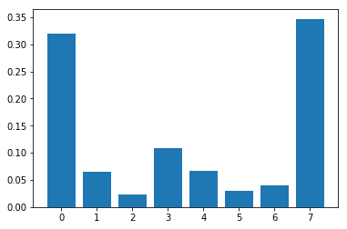

```python
importances = np.mean([tree.feature_importances_ for tree in bgr.estimators_], axis=0)
# summarize feature importance
feature_names = concrete.columns[0:8]
print(feature_names)
for i,v in enumerate(importances):
    print('Feature: %0d, Score: %.5f' % (i,v))
# plot feature importance
pyplot.bar([x for x in range(len(importances))], importances)
pyplot.show()
```

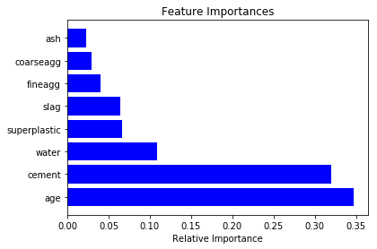

```python
# View a list of the features and their importance scores
importances = np.mean([tree.feature_importances_ for tree in bgr.estimators_], axis=0)
indices = np.argsort(importances)[::-1][:15]
a = concrete.columns[:]
features= a.drop('strength',1)
#plot it
plt.figure(1)
plt.title('Feature Importances')
plt.barh(range(len(indices)), importances[indices], color='b', align='center')
plt.yticks(range(len(indices)), features[indices])
plt.xlabel('Relative Importance')
```

We observed that ageing and cement content play very critical role in defining the strength of concrete, followed by Water and superplasicity.

It is also become evident from importance matrix that fine and coarse aggregate and ash play least role in contribution towards strength of concrete.

It is hence apperant that coarse and fine aggregate and ash are mere the fillers in the concrete mix.

Summary of Accuracy results:

We have observed that out of all the models created:

Linear Regression with original independant variables, accuracy is 73.4%

Linear Regression with original independant variables and Ridge regularization, accuracy is 73.4%

Linear Regression with original independant variables and Lasso regularization, accuracy is 73.7%

Linear Regression with polynomial independant variables with only_interface, accuracy is 77.4%

Linear Regression with polynomial independant variables without only_interface, accuracy is 84% (Using GridCV)

Linear Regression with polynomial independant variables without only_interface and Ridge regularization, accuracy is 84% (Using GridCV)

Linear Regression with polynomial independant variables without only_interface and Lasso regularization, accuracy is 83.6% (Using GridCV)

Decision Tree with polynomial independant variables, accuracy is 65% (Overfit Model)

Decision Tree with polynomial independant variables, accuracy is 56%

Ensemble Technique(Bagging Regressor) with original (8) independant variables, accuracy is 90%

SVM with polynomial independant variables, accuracy is 50%

So we will take nsemble Technique(Bagging Regressor) with original (8) independant variables, as our preffered model to work with.

# Calculation of Accuracy levels at 95% confidence level

```python
from sklearn.model_selection import KFold
from sklearn.model_selection import cross_val_score

num_folds = 50
seed = 7

kfold = KFold(n_splits=num_folds, random_state=seed)
results = cross_val_score(bgr1, X, y, cv=kfold)
print(results)
print("Accuracy: %.3f%% (%.3f%%)" % (results.mean()*100.0, results.std()*100.0))
```

[output not shown]

[output cut: 45 more lines]

[output not shown]

```
[0.79365993 0.95587317 0.67632702 0.83356464 0.92349511 0.84686268
 0.9108475  0.9253429  0.96140297 0.78919765 0.94448862 0.97550941
 0.96636913 0.93945622 0.92327632 0.83043139 0.81624138 0.96390057
 0.91575767 0.9506509  0.93856308 0.89820004 0.97067005 0.72249038
 0.89651809 0.92338541 0.93264535 0.91242933 0.9797531  0.92252961
 0.88399029 0.94510564 0.92744709 0.96644526 0.84695446 0.9366263
 0.88977964 0.89313141 0.89079462 0.90463728 0.93937044 0.89640686
 0.96890476 0.94043708 0.90748313 0.90810149 0.95292606 0.96702383
 0.93171804 0.95109795]
Accuracy: 90.776% (6.269%)
```

```python
print('For 95% level of confidence we should take 2 times sigma from either side of mean accuracy, calculated from muliple folds for validation')
sigma = 6.3
Mean = 90.7
#Lower value of accuracy Range
Al = Mean - 2*sigma
#Upper value of accuracy Range
Au = min((Mean + 2*sigma),100)
```

```
For 95% level of confidence we should take 2 times sigma from either side of mean accuracy, calculated from muliple folds for validation
```

```python
print("At 95 percent confidence level, Accuracy range: %.3f%% - %.3f%%" % (Al, Au))
```

```
At 95 percent confidence level, Accuracy range: 78.100% - 100.000%
```